# Reporte Temporada 2023 (Oct-Dec)

M. Abel Herrera

2023-12-22

# Análisis explotatorio

## Fluorescencia

La siguiente tabla presenta la cantidad de dias de muestreo, el promedio de datos recopilados en cada uno de ellos, y el total recopilado durante toda la temporada por sitio. Los datos no contienen NA’s.

```
##          sitio n_muestreos n_datos_promedio n_datos_totales
## 1 la_esperanza          11               15             165
## 2    rio_claro           8               15             120
```

A continuación se muestran los resultados de tres indicadores de fluorescencia: ΦP0 (Rendimiento Cuántico Máximo del Fotosistema II), ΦE0 (Rendimiento Cuántico Efectivo del Fotosistema II) y Ψ0 (Eficiencia Cuántica Máxima del Fotosistema II).

#### Boxplot

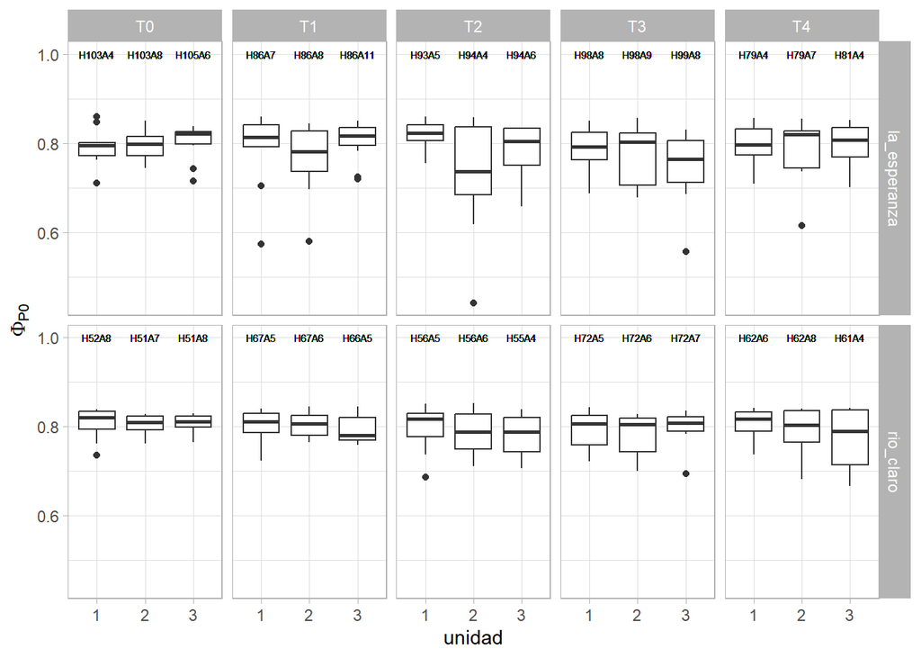

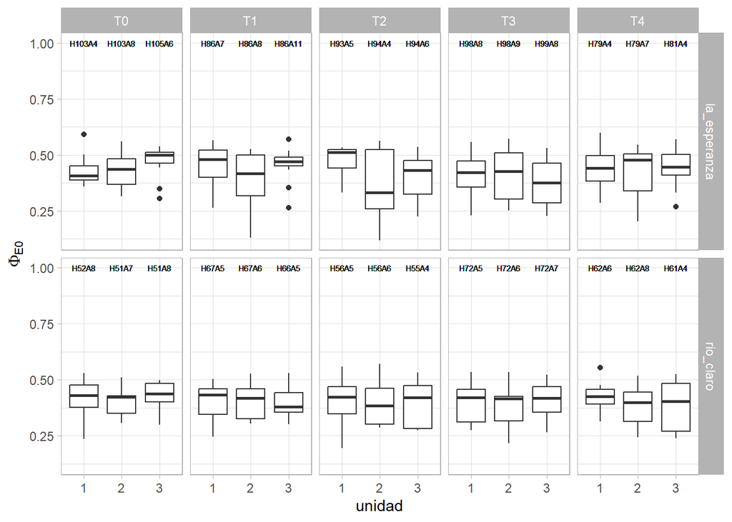

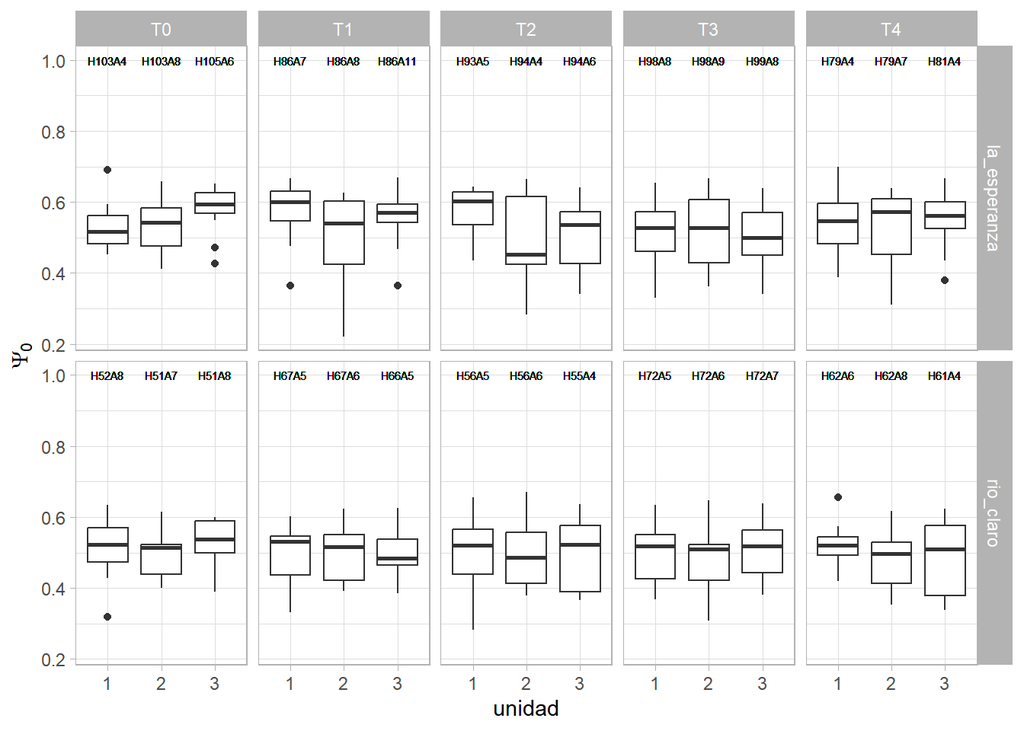

### Serie temporal

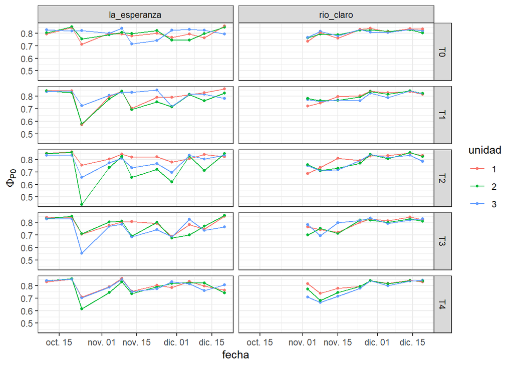

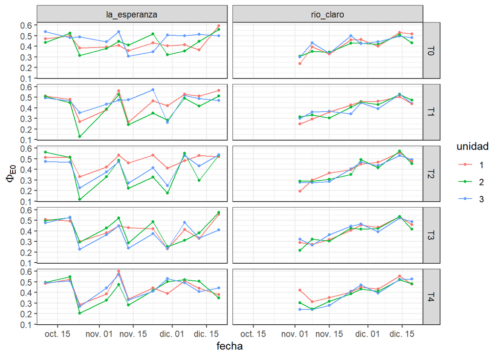

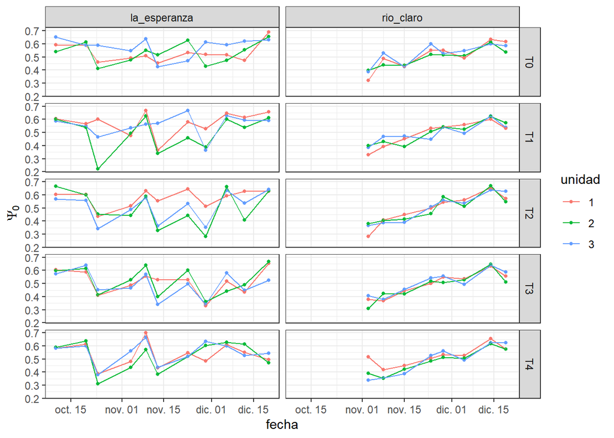

## Potencial

La siguiente tabla presenta la cantidad de días de muestreo, el promedio de datos recopilados en cada uno de ellos, y el total recopilado durante toda la temporada por sitio. Los datos no contienen NA’s.

```
##          sitio n_dias n_datos_promedio n_datos_totales
## 1 la_esperanza     11             14.8             163
## 2    rio_claro      6             14.2              85
```

### Boxplot

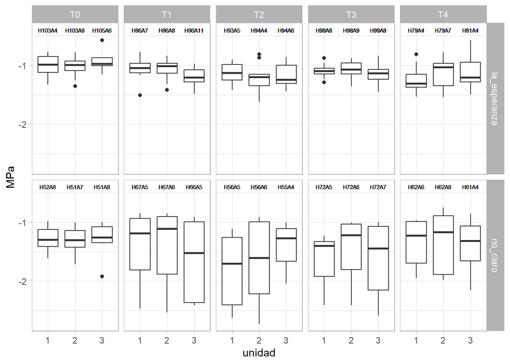

### Serie temporal

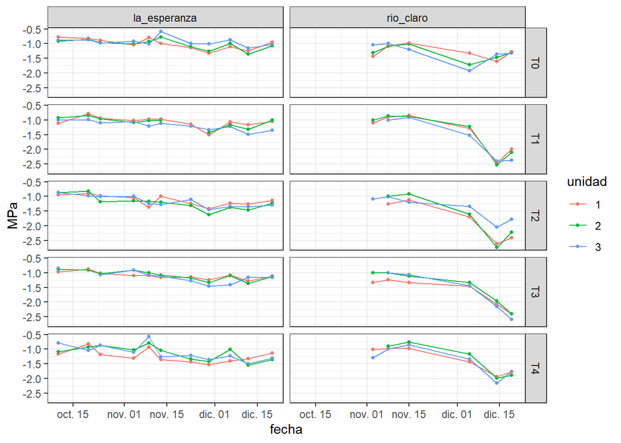

## PAR

La siguiente tabla presenta la cantidad de dias de muestreo, el promedio de datos recopilados en cada uno de ellos, y el total recopilado durante toda la temporada por sitio. Los datos no contienen NA’s.

```
##          sitio n_dias n_datos_promedios n_datos_totales
## 1 la_esperanza      8                 5              40
## 2    rio_claro      6                 5              30
```

### Boxplot

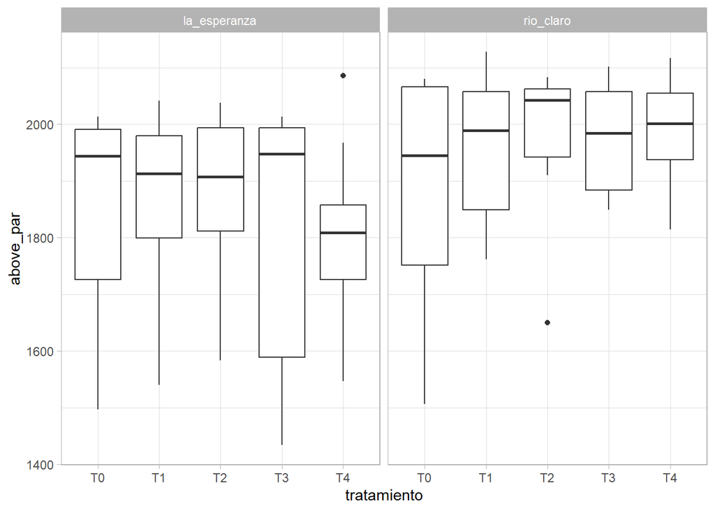

### Serie temporal

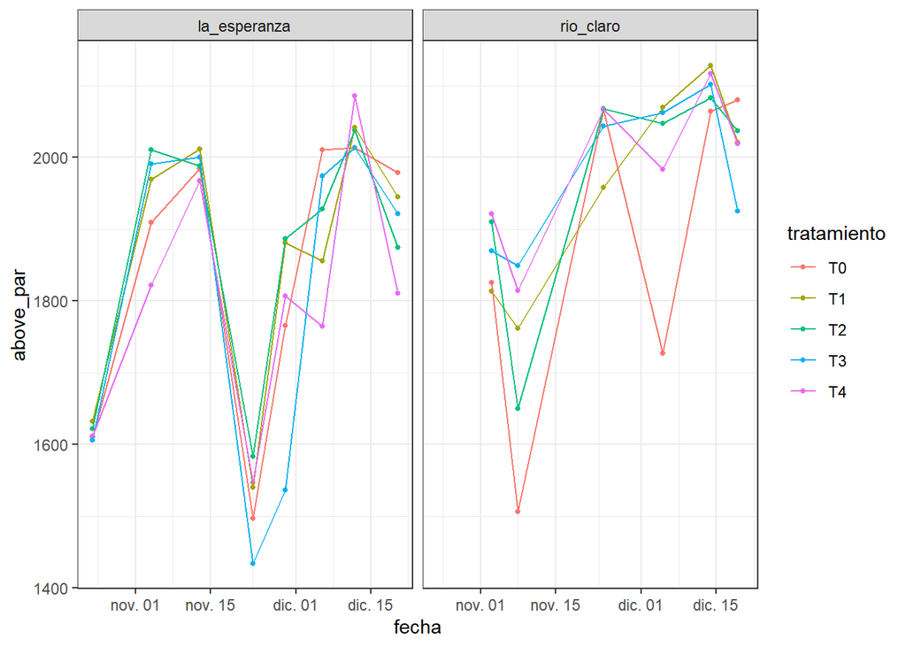

## Humedad del suelo

La siguiente tabla presenta la cantidad de dias de muestreo desde la instalación de los zim, el promedio de datos recopilados en cada uno de ellos, y el total recopilado durante toda la temporada por sitio. Los datos no contienen NA’s.

```
##          sitio n_dias n_datos_promedio n_datos_totales
## 1 la_esperanza     84            208.5           17515
## 2    rio_claro     84            214.2           17989
```

### Boxplot

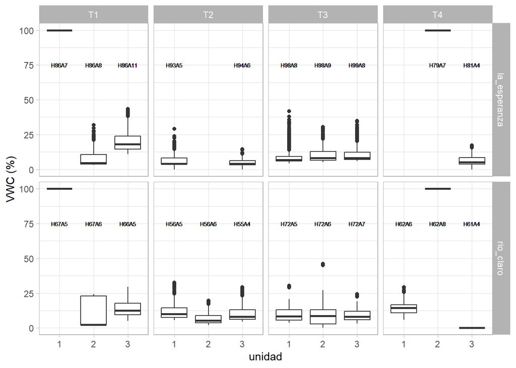

### Serie temporal

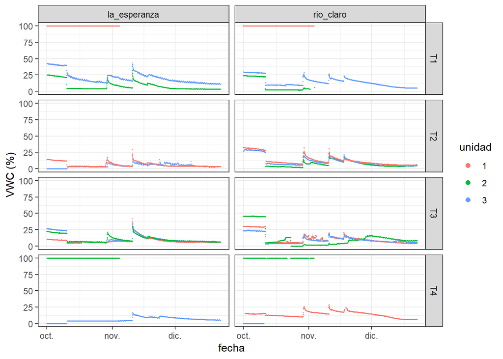

## Presión de parche

La siguiente tabla presenta la cantidad de dias de muestreo desde la instalación de los zim, el promedio de datos recopilados en cada uno de ellos, y el total recopilado durante toda la temporada por sitio. Los datos no contienen NA’s.

```
##          sitio n_dias n_datos_promedio n_datos_totales
## 1 la_esperanza     84            485.8           40803
## 2    rio_claro     84            289.6           24325
```

### Boxplot

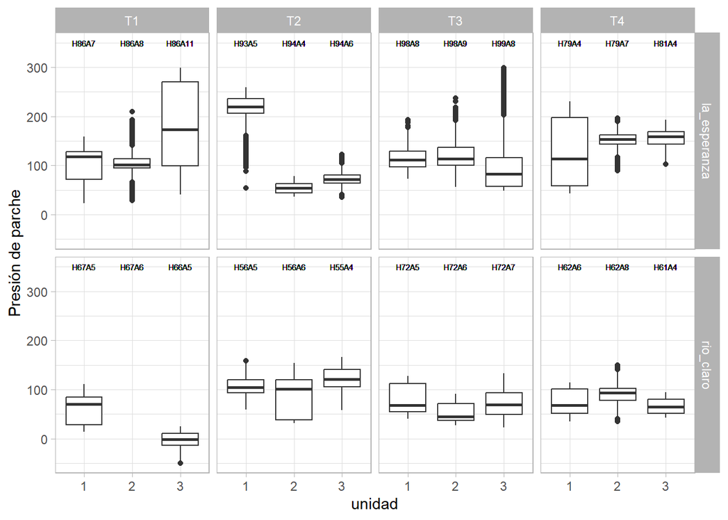

### Serie temporal

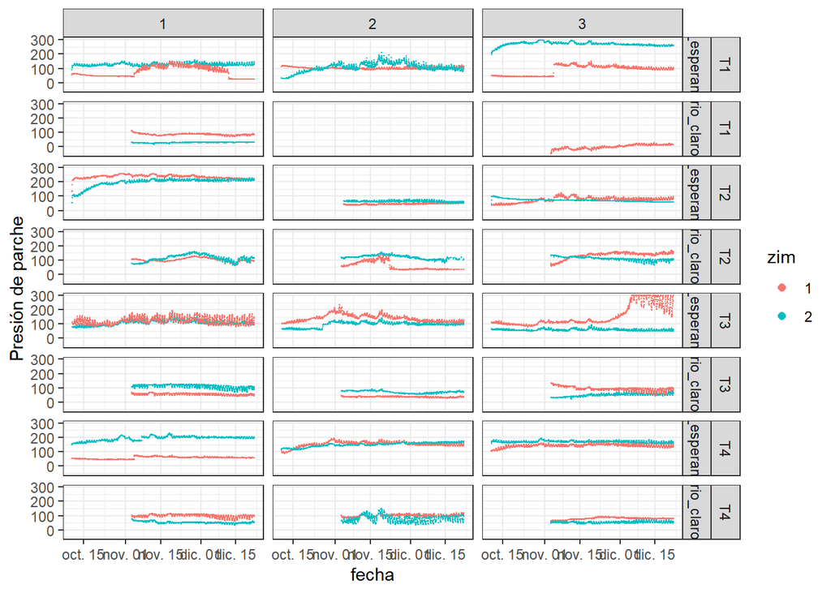

### Ciclo diario

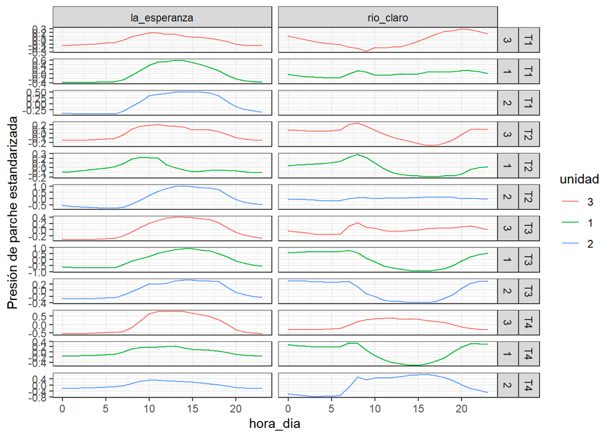